# Linking multispectral fluorescence and Slope Factor

# Chla concentrration estimation with 3X1M fluorometer.

The use of the 3x1m fluorometer rise new possibilities for estimating Chla from in situ fluorescence. We will investigate the lab results to see in what manner the multispectral can be correlated to Chla concentration in a more precise way than the “classic” fluorescence.  
We recall that the lab work consisted of making different measurement of phytoplankton culutures. A dilution scale was made from each original culture.  
In each dilution we have the following measurement : 3X1M, PAM and cytometrie  
For two of them we have HPLC measurement. As we know the dilution factor we can retrieve Chla concentration for each of the dilutions.  
The first thing is to take a look at the accuracy of the fluorescence estimation of [Chla]. We will look at the distribution of the F-to-Chla ratio.

```r
library(tidyverse)

local_path <- here::here() #define the local path
data_path <- paste(local_path, "Boussole/Data/labo/results_reshape.csv", sep ="/")

results <- read_csv(data_path)
```

```r
#define some pigment vec to ease the data manipulation later
pigments <- c("chl_c1_c2", "chl_c3", "peri", "but", "fuco", "diad", "diat", "zea", "dv_chlb", "chlb", "t_chlb", "dv_chla", "chla", "t_chla")

result_long <- results %>%
  rename("chl_c1_c2" = chlorophyll_c1_c2_mg_dvp,
         "chl_c3" = chlorophyll_c3,
         "peri" = peridinin,
         "but" = x19_butanoyloxyfucoxanthin,
         "fuco" = fucoxanthin,
         "diad" = diadinoxanthin,
         "diat" = diatoxanthin,
         "zea" = zeaxanthin,
         "dv_chlb" = divinyl_chlorophyll_b,
         "chlb" = chlorophyll_b,
         "dv_chla" = divinyl_chlorophyll_a,
         "chla" = chlorophyll_a,
         "t_chla" = chla_conc_spectro,
         "f440" = "440nm_mean",
         "f470" = "470nm_mean",
         "f532" = "532nm_mean",
         "fv_fm" = "Fv/Fm") %>%
  filter(!is.na(number_cells)) %>%
  pivot_longer(pigments, names_to = "pigment", values_to = "concentration") %>%
  mutate(cell_conc = concentration/number_cells,
         "f440_f470" = f440/f470,
         "f532_f470" = f532/f470,
         chla_fluo = f470 * 0.007) %>%
  select(strain, replicate, dilution, f440, f470, f532, f440_f470, f532_f470, number_cells, fv_fm, pigment, concentration, cell_conc, chla_fluo)
```

```r
pig_cell = paste(result_long$pigment, "_cell", sep ="")

result_wide <- result_long %>%
  select(-cell_conc) %>%
  pivot_wider(names_from = pigment, values_from = concentration)
result_cell_conc <-  result_long %>%
  mutate(pig_cell = paste(pigment, "_cell", sep = "")) %>%
  select(-concentration, -pigment) %>%
  pivot_wider(names_from = pig_cell, values_from = cell_conc)

result_tot <- left_join(result_wide, result_cell_conc) %>% mutate(common_name = case_when(
  strain %in% c("RCC1717", "RCC76", "RCC4213") ~ "Diatom",
  strain %in% c("RCC162", "RCC156", "PCC9511") ~ "Prochlorococcus",
  strain %in% c("RCC2379", "RCC2374", "RCC2319") ~ "Synechococcus",
  strain %in% c("RCC100") ~ "Pelagophyte",
  strain %in% c("RCC3006") ~ "Dino"
))
```

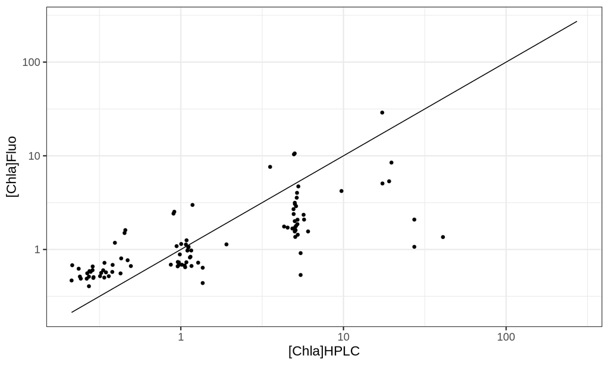

```r
result_tot <- result_tot %>% mutate(slope_factor = chla_fluo/t_chla)
result_tot$fv_fm[result_tot$fv_fm < 0] <- 0

ggplot(filter(result_tot, t_chla > 0.2))+
  geom_point(aes(x = t_chla, y =chla_fluo))+
  geom_line(aes(x = t_chla, y = t_chla))+
  scale_x_log10()+
  scale_y_log10()+
  xlab("[Chla]HPLC")+
  ylab("[Chla]Fluo")+
  theme_bw(base_size = 16)
```

We can see that we are quite far from the perfect fit. Fluorescence tend to overestimate Chla when the concentration is lower than 1 and underestimate otherwise.  
As we proceed by dilution we can hypothesized that the impact of the stress was greater when the dilution was high. We can llok at the Fv/Fm value for each dilution.

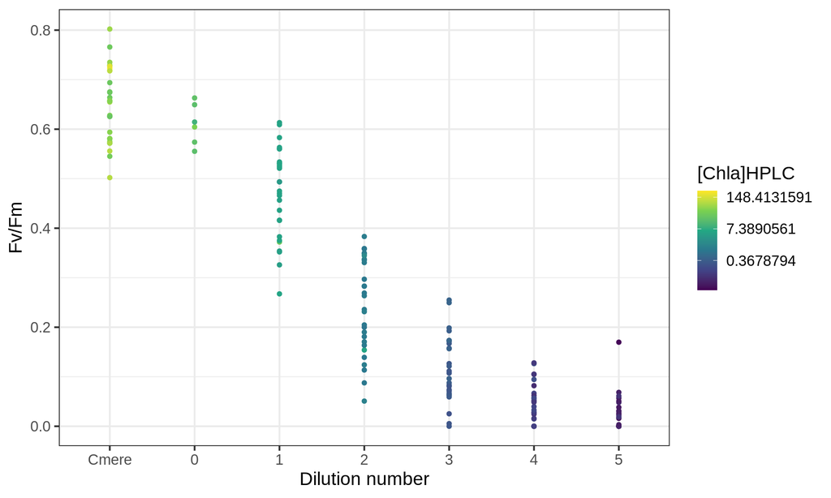

Figure: Evolution of the Fv/Fm value along the dilution

```r
result_tot$dilution <-  factor( result_tot$dilution, levels = c("Cmere", "0", "0bis", "1", "2", "3", "4", "5"))
ggplot(filter(result_tot, dilution != "0bis"))+
  geom_point(aes(x = dilution, y = fv_fm, colour = t_chla))+
  xlab("Dilution number")+
  ylab("Fv/Fm")+
  scale_colour_viridis_c(trans = "log", name = "[Chla]HPLC")+
  theme_bw(base_size = 16)
```

Indeed, we notice that the Fv/Fm value decrease significantly with the dilution. Higher the dilution factor is, lower will be the Fv/Fm. A drop of the Fv/Fm value is interpreted as the result of a stress on the cell (a nutrient depletion for instance). Here, we may face a stress due to the change of medium.  
We can also suppose that this drop of Fv/Fm is a numerical bias due to the devreasing Chla concentration.  
This change of Fv/Fm must be certainly linked to the slope factor, we check this with a simple plot.

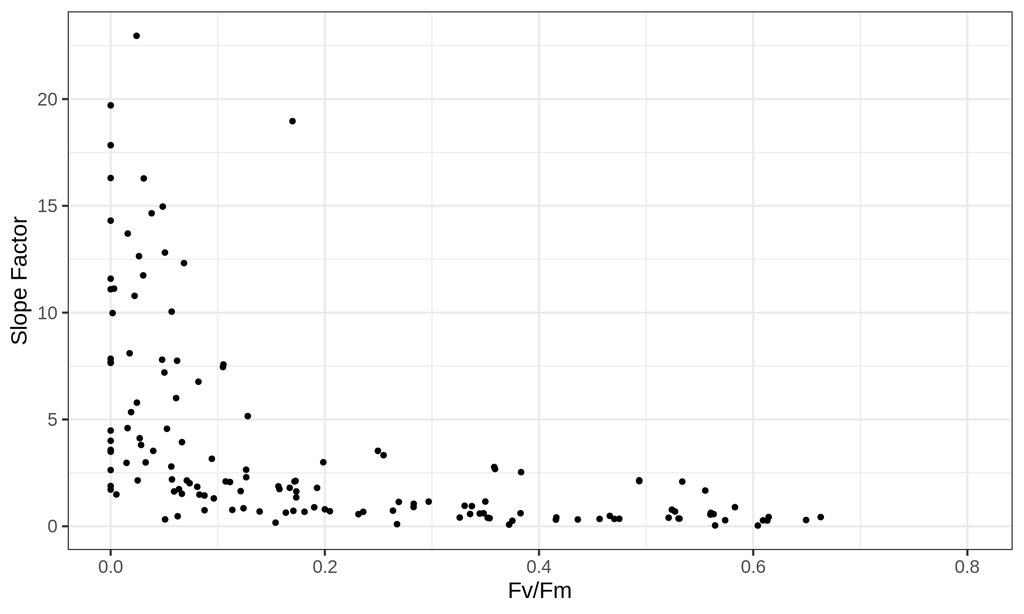

Figure: Relation beween the Slope Factor and Fv/Fm value

```r
ggplot(result_tot)+
  geom_point(aes(x = fv_fm, y = slope_factor))+
  xlab("Fv/Fm")+
  ylab("Slope Factor")+
  theme_bw(base_size = 16)
```

The two variables seems correlated. We can test it with a spearman rank test, as they are not normally distributed.

```r
#non parametric correlation test
data_for_est <- select(result_tot, slope_factor, fv_fm) %>% na.omit()
test <- cor.test(data_for_est$slope_factor, data_for_est$fv_fm, method = "spearman")
test
```

```
##
##  Spearman's rank correlation rho
##
## data:  data_for_est$slope_factor and data_for_est$fv_fm
## S = 859001, p-value < 2.2e-16
## alternative hypothesis: true rho is not equal to 0
## sample estimates:
##        rho
## -0.7626182
```

Indeed there is a significant correlation between the slope factor and the Fv/Fm value.  
The 3X1m can be used to estimate Fv/Fm from the correlation between the F532/F470 ratio, as shown in the plot below.**But I don’t understand WHY ??**

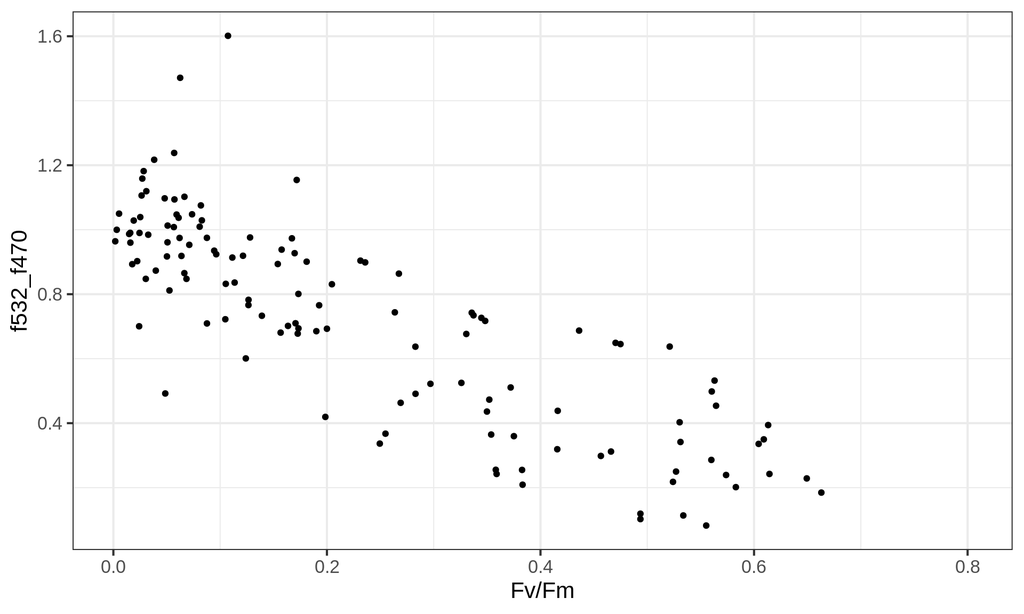

Figure: Relation between F532/F470 ratio and the Fv/Fm value

```r
ggplot(filter(result_tot, fv_fm > 0))+
  geom_point(aes(x = fv_fm, y = f532_f470))+
  scale_colour_viridis_c()+
  xlab("Fv/Fm")+
  theme_bw(base_size = 16)
```

With the following linear regression coefficients.

```r
result_tot_model <- filter(result_tot, fv_fm > 0)
fv_regression = lm(fv_fm ~ f532_f470, data = result_tot_model)

summary(fv_regression)
```

```
##
## Call:
## lm(formula = fv_fm ~ f532_f470, data = result_tot_model)
##
## Residuals:
##      Min       1Q   Median       3Q      Max
## -0.30006 -0.07355 -0.01049  0.05664  0.32270
##
## Coefficients:
##             Estimate Std. Error t value Pr(>|t|)
## (Intercept)  0.59886    0.02404   24.91   <2e-16 ***
## f532_f470   -0.50847    0.03051  -16.67   <2e-16 ***
## ---
## Signif. codes:  0 '***' 0.001 '**' 0.01 '*' 0.05 '.' 0.1 ' ' 1
##
## Residual standard error: 0.1085 on 125 degrees of freedom
##   (27 observations effacées parce que manquantes)
## Multiple R-squared:  0.6896, Adjusted R-squared:  0.6872
## F-statistic: 277.8 on 1 and 125 DF,  p-value: < 2.2e-16
```

But can we **transpose those correlation directly on our in situ data**?  
Let’s check this out. We first load the bouss HPLC/echo multiplexer dataset, and take a look at the slope factor value.

```r
data_path <- paste(local_path, "Boussole/Output/Data/Compiled/hplc_mf_clusterised.csv", sep ="/")
data_ca <- read_csv(data_path)
```

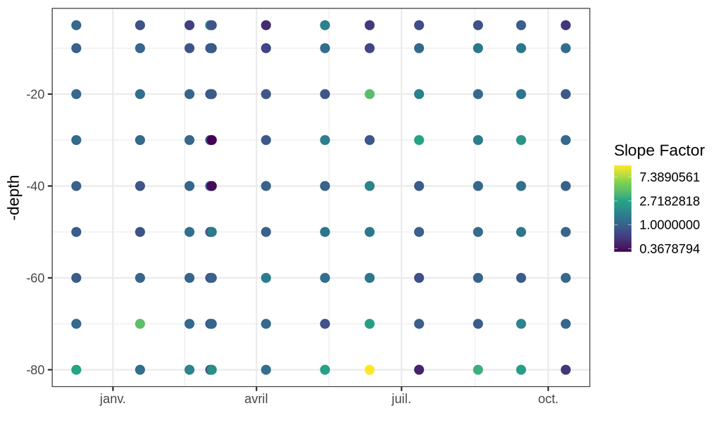

Figure: Slope factor value along the time series at the Boussole site (log color scale)

```r
data_ca$fv_fm = predict(fv_regression, data_ca)

data_ca <- data_ca %>% mutate(chla_fluo = (fluo_470 - 45) * 0.007,
                               slope_factor = chla_fluo/t_chla)

ggplot(filter(data_ca, slope_factor > 0))+
  geom_point(aes(x = date, y = -depth, colour = slope_factor), size = 4)+
  scale_size(guide = "none")+
  xlab("")+
  theme_bw(base_size = 16)+
  scale_color_viridis_c(trans = "log", name = "Slope Factor")
```

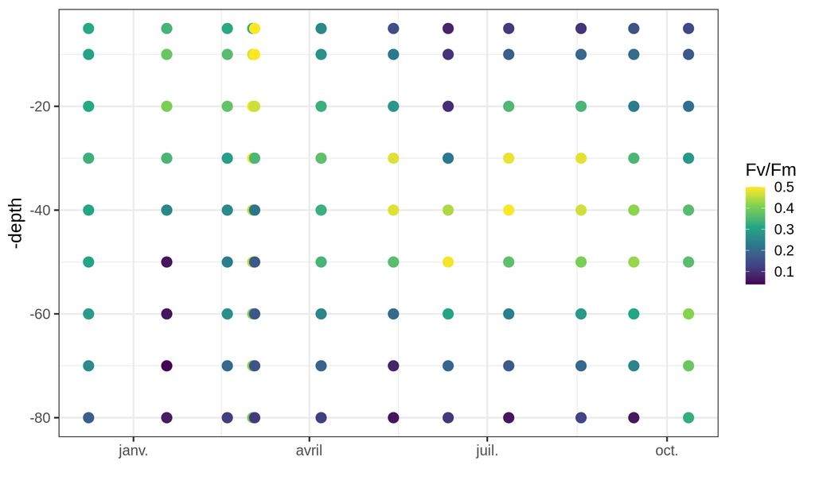

Figure: Fv/Fm value along the time series at the Boussole Site

```r
ggplot(filter(data_ca, slope_factor > 0))+
  geom_point(aes(x = date, y = -depth, colour = fv_fm), size = 4)+
  scale_size(guide = "none")+
  xlab("")+
  theme_bw(base_size = 16)+
  scale_color_viridis_c(name = "Fv/Fm")
```

```r
chla_ms <- lm(t_chla~fluo_470 + fluo_532, data = data_ca)
chla_470 <- lm(t_chla ~fluo_440, data = data_ca)

data_ca$new_fluo_470 <- predict(chla_470, data_ca)
data_ca$new_fluo_ms <- predict(chla_ms, data_ca)

data_ca <- data_ca %>%
    mutate(sf_470 = new_fluo_470/t_chla,
           sf_ms = new_fluo_ms/t_chla)
```

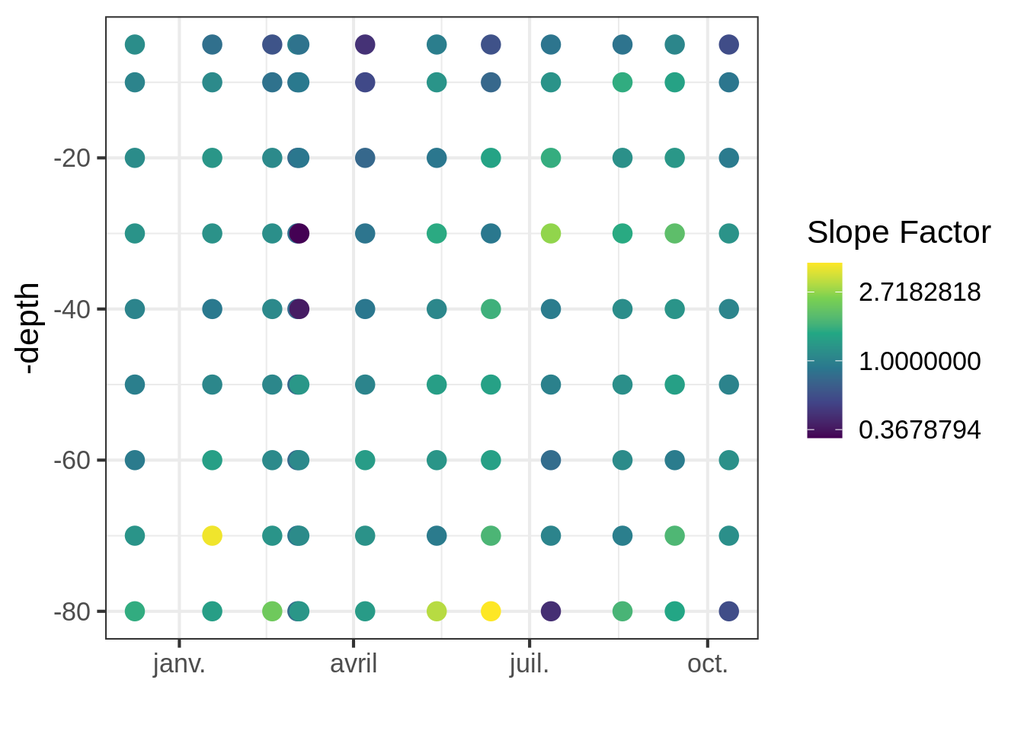

```r
ggplot(filter(data_ca, slope_factor > 0))+
  geom_point(aes(x = date, y = -depth, colour = sf_ms), size = 4)+
  scale_size(guide = "none")+
  xlab("")+
  theme_bw(base_size = 16)+
  scale_color_viridis_c(trans = "log", name = "Slope Factor")
```

```r
rmse <- function(error){
  sqrt(mean(error^2))
}
```

from this model, we can predict the slope factor (i.e. a correction factor) from the F532_F470 value. We can try to apply it on fluorescence data to correction chla concentration estimation;

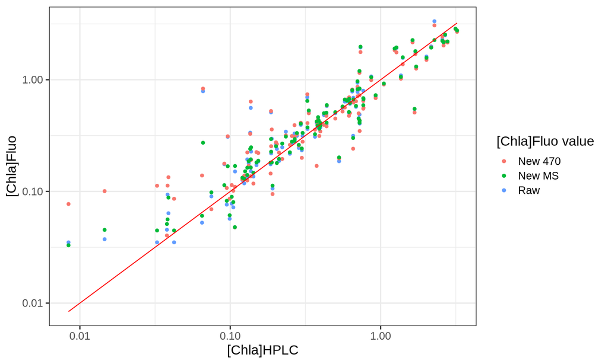

Figure: Comparison of the Chla]Fluo correlation to [Chla]HPLC with the correlation between the corrected value and [Chla]HPLC

```r
ggplot(data_ca)+
  geom_point(aes(x = t_chla, y = chla_fluo, colour = "Raw"))+
  geom_point(aes(x = t_chla, y = new_fluo_470, colour = "New 470"))+
  geom_point(aes(x = t_chla, y = new_fluo_ms, colour = "New MS"))+
  geom_line(aes(x = t_chla, y = t_chla), colour = "red")+
  theme_bw(base_size = 16)+
  xlab("[Chla]HPLC")+
  ylab("[Chla]Fluo")+
  scale_y_log10()+
  scale_x_log10()+
  scale_color_discrete(name = "[Chla]Fluo value")
```

```r
error_fluo <- data_ca$t_chla - data_ca$new_fluo_470
error_ms <- data_ca$t_chla - data_ca$new_fluo_ms
rmse_fluo <- rmse(error_fluo)
rmse_ms <- rmse(error_ms)

print(paste("RMSE of the fluorescence measurement is ", round(rmse_fluo, 2),
            "mg.m-3, while it is only", round(rmse_ms, 2), "mg.m-3 with the correction"))
```

```
## [1] "RMSE of the fluorescence measurement is  0.28 mg.m-3, while it is only 0.25 mg.m-3 with the correction"
```

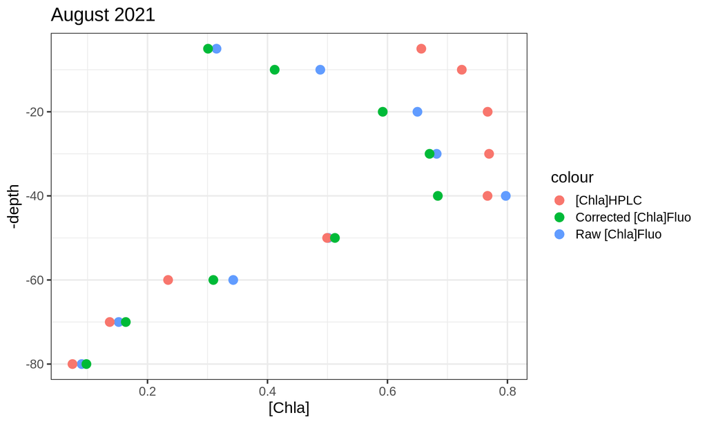

Figure: COmparison of raw and corrected fluo on a profile of the Boussole time series

```r
ggplot(filter(data_ca, bouss == 229))+
  geom_point(aes(x = chla_fluo, y = -depth, colour = "Raw [Chla]Fluo"), size = 4)+
  geom_point(aes(x = t_chla, y = - depth, colour = "[Chla]HPLC"), size = 4)+
  geom_point(aes(x = new_fluo_ms, y = -depth, colour = "Corrected [Chla]Fluo"), size = 4)+
  theme_bw(base_size = 16)+
  xlab("[Chla]")+
  ggtitle("August 2021")
```

```r
library(FactoMineR)
pig_ca <- result_tot_model %>% select(chl_c1_c2:dv_chla) %>% mutate(pig_sum = rowSums(.)) %>%
  filter(pig_sum > 0) %>%
  select(-pig_sum)

pig_insitu <- data_ca %>% select(all_of(colnames(pig_ca))) %>%
  mutate(pig_sum = rowSums(.)) %>%
  filter(pig_sum > 0) %>%
  select(-pig_sum) %>%
  mutate(origin = "insitu")

pig_ca <- mutate(pig_ca, origin = "lab")

pig_tot <- bind_rows(pig_ca, pig_insitu)
index <- which(pig_tot$origin == "insitu")

afc <- CA(select(pig_tot, -origin), row.sup = index, graph = FALSE)

pig_and_name <- result_tot_model %>% select(common_name, chl_c1_c2:dv_chla) %>%
  right_join(.,pig_tot)
```

[output not shown]

```r
library(scales)
library(grid)
library(gridExtra)
```

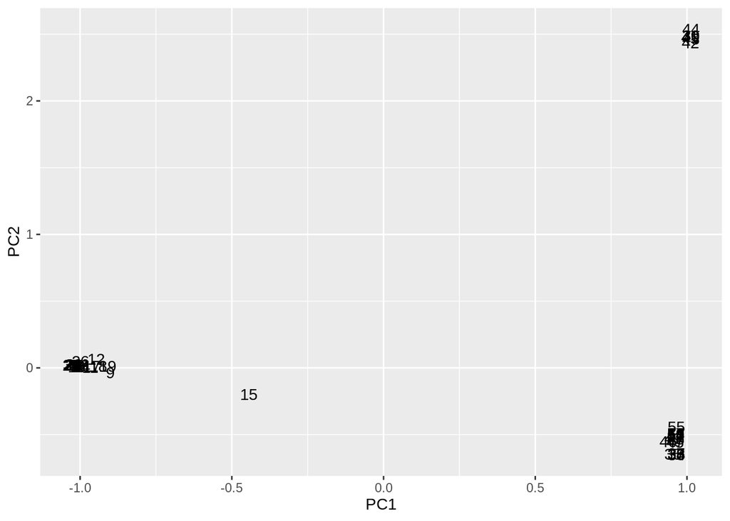

```r
# extract some parts for plotting
PC1 <- afc$row$coord[,1]
PC2 <- afc$row$coord[,2]
labs <- rownames(afc$row$coord)
PCs <- data.frame(cbind(PC1,PC2))
rownames(PCs) <- labs
#
# Just showing the individual samples...
ggplot(PCs, aes(PC1,PC2, label=rownames(PCs))) +
  geom_text()
```

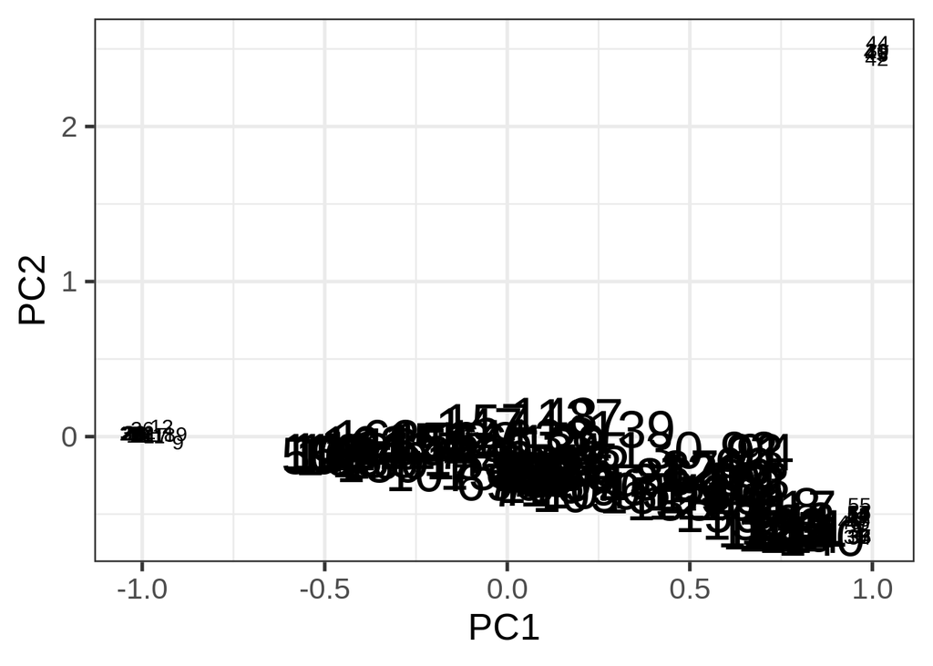

```r
#
#
# Now get supplementary categorical variables
supPC1 <- afc$row.sup$coor[,1]
supPC2 <- afc$row.sup$coor[,2]
clabs <- rownames(afc$row.sup$coor)
cPCs <- data.frame(cbind(supPC1,supPC2))
rownames(cPCs) <- clabs
colnames(cPCs) <- colnames(PCs)
#
# Put samples and categorical variables (ie. grouping
# of samples) all together
p <- ggplot() + theme_bw(base_size = 20)
# no data so there's nothing to plot...
# add on data
p <- p + geom_text(data=PCs, aes(x=PC1,y=PC2,label=rownames(PCs)), size=4)
p <- p + geom_text(data=cPCs, aes(x=PC1,y=PC2,label=rownames(cPCs)),size=10)
p # show plot with both layers
```

```r
#
# clear the plot
dev.off()
```

```r
#
# Now do extract variables
#
vPC1 <- afc$col$coord[,1]
vPC2 <- afc$col$coord[,2]
vlabs <- rownames(afc$col$coord)
vPCs <- data.frame(cbind(vPC1,vPC2))
rownames(vPCs) <- vlabs
colnames(vPCs) <- colnames(PCs)
#
# and plot them
#
pv <- ggplot() + theme_bw(base_size = 20)
# no data so there's nothing to plot
# put a faint circle there, as is customary
angle <- seq(-pi, pi, length = 50)
df <- data.frame(x = sin(angle), y = cos(angle))
pv <- pv + geom_path(aes(x, y), data = df, colour="grey70")
#
# add on arrows and variable labels
pv <- pv + geom_text(data=vPCs, aes(x=vPC1,y=vPC2,label=rownames(vPCs)), size=4) + xlab("PC1") + ylab("PC2")
pv <- pv + geom_segment(data=vPCs, aes(x = 0, y = 0, xend = vPC1*0.9, yend = vPC2*0.9), arrow = arrow(length = unit(1/2, 'picas')), color = "grey30")
pv # show plot
#
# clear the plot
dev.off()
```

[output not shown]

```r
#
# Now put them side by side
#
library(gridExtra)
grid.arrange(p,pv,nrow=1)
#
# Now they can be saved or exported...
#
# tidy up by deleting the plots
#
dev.off()
```

[output not shown]

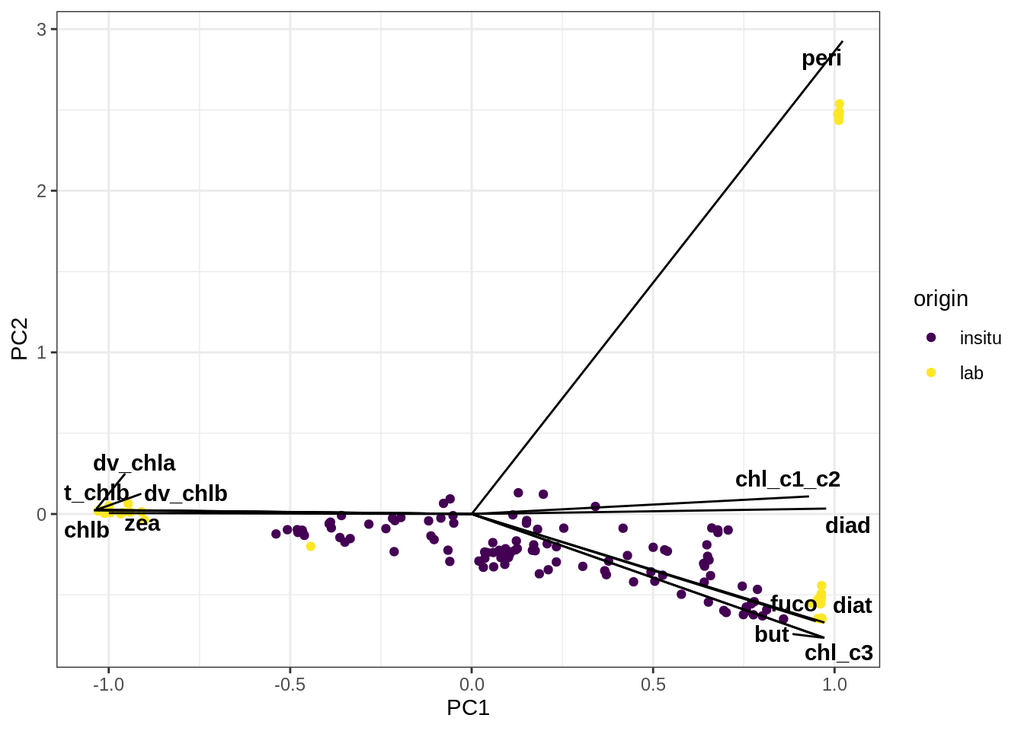

```r
library(ggrepel)
coord_df <- bind_rows(PCs, cPCs)

pig_and_name <- bind_cols(pig_and_name, coord_df)

ggplot(pig_and_name)+
  geom_point(aes(x = PC1, y = PC2, colour = origin))+
  geom_segment(aes(x = 0, y = 0, xend =PC1, yend = PC2), data = vPCs)+
  geom_text_repel(aes(x = PC1, y = PC2, label=rownames(vPCs), fontface = 2), data = vPCs)+
  scale_color_viridis_d()+
  theme_bw()
```